# m-IF_immune panel

Sara Söderqvist

2024-10-17

This script explores whether two macrophage types, defined below by their marker expression, are differentially expressed between lobule and stroma.

In brief, larger annotations of lobules and stroma were created in qupath (ROIs, regions of interest). Each ROI was in the vincinity of tumor. Within, cell detection was performed, and a clean-up to enrich for immune cells only was applied. The clean-up consisted of: removal of PanCK+ cells, removal of cells with very elongated nucleus (these would be more likely to be stromal cells and not immune cells).

In this pipeline, CD68 will be used as pan-macrophage marker, (nb, a pan-monocyte marker). Cells double positive for CD163 and CD68 are called M2 type of macrophage. CD163- CD69+ cells will be called M1 macrophages.

```r
library(rstatix)
library(dplyr)
```

```r
library(reshape2)
library(ggplot2)
library(tidyr)
library(ggpubr)
library(ggthemes)
```

```r
setwd("/Users/sara.soderqvist/Library/CloudStorage/OneDrive-KarolinskaInstitutet/Writing_/Adaptive PDAC paper/Code/source data files to read in/m-IF immune") #Adjust working directory
immunepanel_cleaned = read.csv("read in_m-IF_immune.csv")

immunepanel_cleaned <- immunepanel_cleaned[, -c(3, 4, 7)]
```

```r
#Create individual columns displaying whether cells are positive for a given stain. This information is extracted from the column "Classification", as determined by the qupath classifier.
immunepanel_cleaned$CD68_pos <- factor(nrow(immunepanel_cleaned))
immunepanel_cleaned$CD163_pos <- factor(nrow(immunepanel_cleaned))
immunepanel_cleaned$CD56_pos <- factor(nrow(immunepanel_cleaned))
immunepanel_cleaned$NKp46_pos <- factor(nrow(immunepanel_cleaned))
immunepanel_cleaned$CD3_pos <- factor(nrow(immunepanel_cleaned))

immunepanel_cleaned <- immunepanel_cleaned %>% mutate(CD68_pos = ifelse(grepl('CD68_pos:', immunepanel_cleaned$Classification), '1', .$CD68_pos))
immunepanel_cleaned <- immunepanel_cleaned %>% mutate(CD68_pos = ifelse(grepl('CD68_neg:', immunepanel_cleaned$Classification), '0', .$CD68_pos))
immunepanel_cleaned <- immunepanel_cleaned %>% mutate(CD163_pos = ifelse(grepl(': CD163_pos', immunepanel_cleaned$Classification), '1', .$CD163_pos))
immunepanel_cleaned <- immunepanel_cleaned %>% mutate(CD163_pos = ifelse(grepl(': CD163_neg', immunepanel_cleaned$Classification), '0', .$CD163_pos))
immunepanel_cleaned <- immunepanel_cleaned %>% mutate(CD56_pos = ifelse(grepl('CD56_pos: ', immunepanel_cleaned$Classification), '1', .$CD56_pos))
immunepanel_cleaned <- immunepanel_cleaned %>% mutate(CD56_pos = ifelse(grepl('CD56_neg: ', immunepanel_cleaned$Classification), '0', .$CD56_pos))
immunepanel_cleaned <- immunepanel_cleaned %>% mutate(NKp46_pos = ifelse(grepl(' NKp46_pos: ', immunepanel_cleaned$Classification), '1', .$NKp46_pos))
immunepanel_cleaned <- immunepanel_cleaned %>% mutate(NKp46_pos = ifelse(grepl(' NKp46_neg: ', immunepanel_cleaned$Classification), '0', .$NKp46_pos))
immunepanel_cleaned <- immunepanel_cleaned %>% mutate(CD3_pos = ifelse(grepl('CD3_pos', immunepanel_cleaned$Classification), '1', .$CD3_pos))
immunepanel_cleaned <- immunepanel_cleaned %>% mutate(CD3_pos = ifelse(grepl('CD3_neg', immunepanel_cleaned$Classification), '0', .$CD3_pos)) # 176 422 cells, same as the original read in file.
# 1 row = 1 cell.
```

```r
# the goal is to show what immune cells, specifically macrophages, exist in lobules and in stroma.
# Format the data to enable calculation of fractions of positive cells, depending on the ROI identity:

immunepanel_cleaned_cell <- immunepanel_cleaned[, -c(3, 5, 6)]

immune_cleaned_cell <- melt(immunepanel_cleaned_cell, id = c("Image", "Object.ID", "Parent"))
colnames(immune_cleaned_cell) [4] <- "Stain"
colnames(immune_cleaned_cell) [5] <- "Cell_pos"

immune_cleaned_cell <- separate(data = immune_cleaned_cell, col = "Image", into="Image", sep=c("_"), remove=TRUE)
immune_cleaned_cell$Group <- character(nrow(immune_cleaned_cell))
immune_cleaned_cell$Group <- paste(immune_cleaned_cell$Image, immune_cleaned_cell$Parent, immune_cleaned_cell$Stain, sep = "_")
```

```r
s_immune_cleaned_cell <- split(immune_cleaned_cell, f = immune_cleaned_cell$Group)

# Fraction calculation. Note that this does not take into account wheather individual cells are double positive etc. for other markers.
tot_det_immune_cleaned_cell <- lapply(X = s_immune_cleaned_cell, FUN = function (x) {
  x$sum_detections_ROI <- nrow(x)
  x
})

fun_immunecells_cleaned_frac <- function (z) {
  nr_pos<- z %>% filter(Cell_pos == "1") # get nr positive cells for each stain
  pos_fr <- nrow(nr_pos)/nrow(z) #calculate the fraction out of all the cells in that specific ROI
  z$pos_fraction <- pos_fr # put the calculated fraction in a column; "pos_fr"
  z
}

immunecells_cleaned_calc_fr <- lapply (X = tot_det_immune_cleaned_cell, FUN = fun_immunecells_cleaned_frac)

immunecells_calc_frsub_cleaned <- bind_rows(immunecells_cleaned_calc_fr) #882 110 rows
immunecells_calc_frsub_cleaned <- immunecells_calc_frsub_cleaned[, -c(2, 5)]

immunecells_calc_frsub_cleaned_roi <- unique(immunecells_calc_frsub_cleaned) # 370 rows

# Clearer grouping column; the compartment identity of the ROI (lobular or stromal)
immunecells_calc_frsub_cleaned_roi$Compartment <- factor(nrow(immunecells_calc_frsub_cleaned_roi))
immunecells_calc_frsub_cleaned_roi <- immunecells_calc_frsub_cleaned_roi %>% mutate(Compartment = ifelse(grepl('Lobule', immunecells_calc_frsub_cleaned_roi$Parent), 'Lobule', .$Compartment))
immunecells_calc_frsub_cleaned_roi <- immunecells_calc_frsub_cleaned_roi %>% mutate(Compartment = ifelse(grepl('Stroma', immunecells_calc_frsub_cleaned_roi$Parent), 'Stroma', .$Compartment))
```

```r
boxes_pan_immune_cleaned_sp<- ggboxplot(immunecells_calc_frsub_cleaned_roi, x = "Stain", y = "pos_fraction",
                        color = "Compartment", fill = "Compartment", alpha=0.6) +
  scale_color_brewer(palette= "Set2", type = "qual") +
  scale_fill_brewer(palette= "Set2", type = "qual") +
  labs(title = "Fractions of cells with positive immune cells' markers in lobular and stromal ROIs", subtitle = "General single markers' expression") +
  xlab(NULL) + ylab("Average positive cells per ROI") +
  theme_clean()

wilcox_pan_immune_cleaned <- immunecells_calc_frsub_cleaned_roi %>%
  group_by(Stain) %>%
  wilcox_test(pos_fraction ~ Compartment) %>%
  adjust_pvalue(method = "BH") %>%
  add_significance("p.adj")

wilcox_pan_immune_cleaned <- wilcox_pan_immune_cleaned %>% add_xy_position(x = "Stain")
wilcox_pan_immune_cleaned
```

```
## # A tibble: 5 × 15
##   Stain    .y.   group1 group2    n1    n2 statistic       p  p.adj p.adj.signif
##   <fct>    <chr> <chr>  <chr>  <int> <int>     <dbl>   <dbl>  <dbl> <chr>
## 1 CD68_pos pos_… Lobule Stroma    34    40       917 0.00973 0.0487 *
## 2 CD163_p… pos_… Lobule Stroma    34    40       846 0.0725  0.181  ns
## 3 CD56_pos pos_… Lobule Stroma    34    40       790 0.234   0.39   ns
## 4 NKp46_p… pos_… Lobule Stroma    34    40       742 0.504   0.535  ns
## 5 CD3_pos  pos_… Lobule Stroma    34    40       622 0.535   0.535  ns
## # ℹ 5 more variables: y.position <dbl>, groups <named list>, x <dbl>,
## #   xmin <dbl>, xmax <dbl>
```

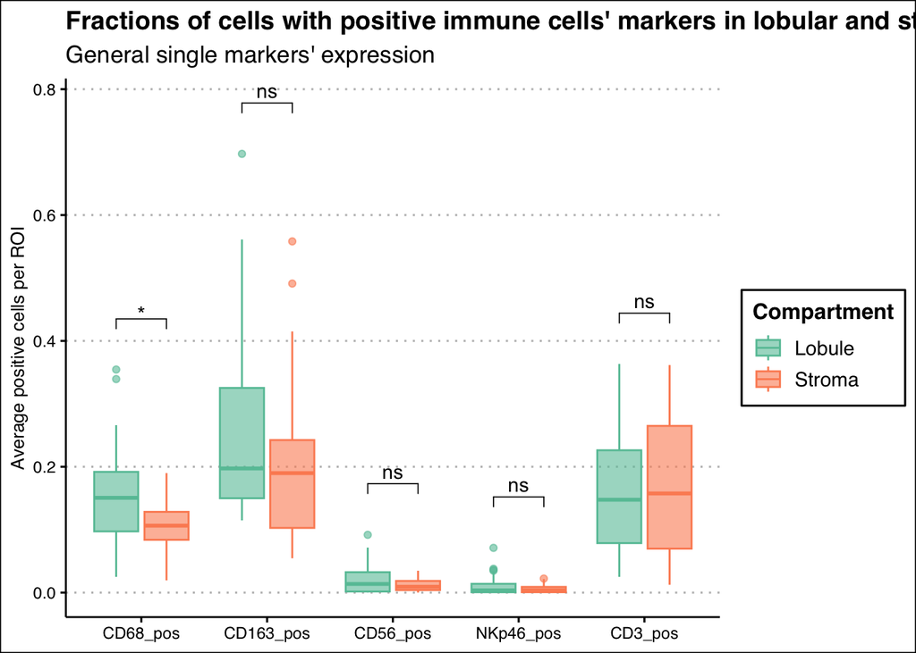

```r
boxes_pan_immune_sp_cleaned_sign <- boxes_pan_immune_cleaned_sp + stat_pvalue_manual(label = "p.adj.signif",
                                                    wilcox_pan_immune_cleaned, tip.length = 0.02)
boxes_pan_immune_sp_cleaned_sign
```

Focused research question: are M1 and M2 macrophages (Mø) and their ratio differentially expressed between lobule and stroma?

1. How many of each Mø subtype are there, the total counts?

```r
# Recall subtypes:
# M2 mø = CD68+CD163+
# M1 mø = CD68+CD163-

#1) remove all cells that are positive for CD3 ( they are T cells)
#immunepanel_cleaned derived

non_CD3 <- dplyr::filter(immunepanel_cleaned, paste(CD3_pos) == '0')

# 2) keep all cells that are positive for either CD163 or CD68
mo <- non_CD3 %>%
  filter(CD163_pos == 1 | CD68_pos == 1)

mo$mo_subtype <- factor(nrow(mo))
mo <- mo %>% mutate(mo_subtype = ifelse(grepl('1', mo$CD68_pos) & grepl('1', mo$CD163_pos), 'CD68+_CD163+', .$mo_subtype))
mo <- mo %>% mutate(mo_subtype = ifelse(grepl('1', mo$CD68_pos) & grepl('0', mo$CD163_pos), 'CD68+_CD163-',.$mo_subtype))
mo <- mo %>% mutate(mo_subtype = ifelse(grepl('0', mo$CD68_pos) & grepl('1', mo$CD163_pos), 'CD68-_CD163+',.$mo_subtype))

mo$Compartment <- factor(nrow(mo))
mo <- mo %>% mutate(Compartment = ifelse(grepl('Lobule', mo$Parent), 'Lobule', .$Compartment))
mo <- mo %>% mutate(Compartment = ifelse(grepl('Stroma', mo$Parent), 'Stroma', .$Compartment))
```

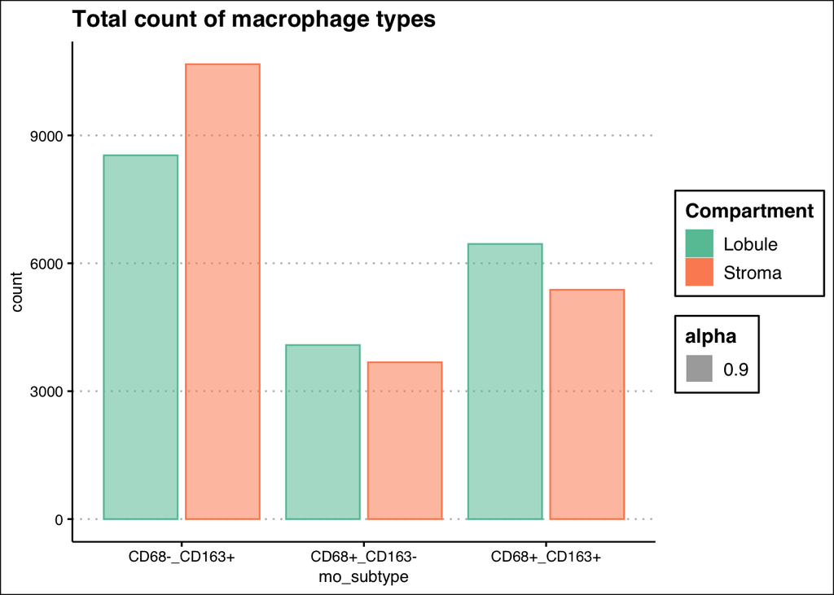

```r
bar_mo <- ggplot(mo, aes(x = mo_subtype, color = Compartment, fill = Compartment, alpha = 0.9)) +
  geom_bar(stat = "count", position = position_dodge2(width = 0.5, preserve = "single")) +
    scale_color_brewer(palette= "Set2", type = "qual") +
  scale_fill_brewer(palette= "Set2", type = "qual") +
  labs(title = "Total count of macrophage types") +
  theme_clean()
bar_mo
```

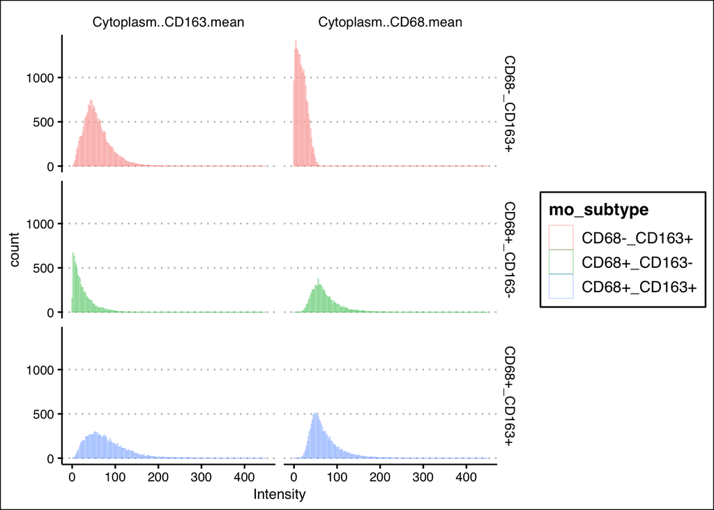

```r
mo_cell <- mo[, -c(3, 7:11)]

melt_mo_cell <- melt(mo_cell, id = c("Image", "Object.ID", "Parent", "mo_subtype", "Compartment"))
colnames(melt_mo_cell) [6] <- "Stain"
colnames(melt_mo_cell) [7] <- "Intensity"

melt_mo_cell <- separate(data = melt_mo_cell, col = "Image", into="Image", sep=c("_"), remove=TRUE)
melt_mo_cell$Group <- character(nrow(melt_mo_cell))
melt_mo_cell$Group <- paste(melt_mo_cell$Image, melt_mo_cell$Parent, melt_mo_cell$Stain, sep = "_")

# histogram of mo:s intensity of the two stains of interest

hist_mo <- gghistogram(melt_mo_cell, x = "Intensity", color = "mo_subtype", alpha = 0.4, bins = 200, size = 0.1) +
  facet_grid(mo_subtype~Stain) +
  theme_clean()
hist_mo
```

```r
s_mo <- split(melt_mo_cell, f = melt_mo_cell$Group)

tot_det_s_mo <- lapply(X = s_mo, FUN = function (x) {
  x$sum_detections_ROI <- nrow(x)
  x
})

# new functions to calculate mo subtype fractions in each ROI:
fun_immunecells_frac_mo <- function (z) {
  nr_M2<- z %>% filter(mo_subtype == "CD68+_CD163+") # get nr of M2 mo:s in the ROI
  M2pos_fr <- nrow(nr_M2)/nrow(z) #calculate the fraction of M2 mo:s out of all the cells in this specific ROI
  z$M2pos_fraction <- M2pos_fr # put M2 fraction in a column

  nr_M1<- z %>% filter(mo_subtype == "CD68+_CD163-") # get nr of M1 mo:s in the ROI
  M1pos_fr <- nrow(nr_M1)/nrow(z) #calculate the fraction of M1 mo:s out of all the cells in this specific ROI
  z$M1pos_fraction <- M1pos_fr # put M1 fraction in a column

  nr_CD163<- z %>% filter(mo_subtype == "CD68-_CD163+") # get nr of M1 mo:s in the ROI
  CD163pos_fr <- nrow(nr_CD163)/nrow(z) #calculate the fraction of M1 mo:s out of all the cells in this specific ROI
  z$CD163pos_fr <- CD163pos_fr # put cell id fraction in a column

  z
}

immunecells_calc_fr_mo <- lapply (X = tot_det_s_mo, FUN = fun_immunecells_frac_mo)

immunecells_calc_frsub_mo <- bind_rows(immunecells_calc_fr_mo) #77 576 rows . 1 row for each cell.

immunecells_calc_frsub_mo <- immunecells_calc_frsub_mo[, -c(2, 4, 6:8)] #remove cell-specific row information: "group", enabling unique-ing to the ROIs in next command
immunecells_calc_frsub_roi_mo <- unique(immunecells_calc_frsub_mo) # 74 rows. 1 row for each ROI.

#melt
melt_mofractions <- melt(immunecells_calc_frsub_roi_mo, id = c("Image", "Parent", "Compartment", "sum_detections_ROI"), variable.name = "Immune_subtype", value.name = "Pos_fraction") # 222 rows = 74*3. 3 cell types per ROI.
head(melt_mofractions)
```

```
##       Image                           Parent Compartment sum_detections_ROI
## 1 PKR-11,Mq Annotation (Lobule_partiallyd_B)      Lobule                303
## 2 PKR-11,Mq      Annotation (Lobule_wellp_D)      Lobule                314
## 3 PKR-11,Mq            Annotation (Stroma_A)      Stroma                345
## 4 PKR-11,Mq            Annotation (Stroma_B)      Stroma                424
## 5 PKR-11,Mq            Annotation (Stroma_C)      Stroma                612
## 6 PKR-11,Mq            Annotation (Stroma_D)      Stroma                590
##   Immune_subtype Pos_fraction
## 1 M2pos_fraction    0.2871287
## 2 M2pos_fraction    0.3789809
## 3 M2pos_fraction    0.2550725
## 4 M2pos_fraction    0.1721698
## 5 M2pos_fraction    0.2467320
## 6 M2pos_fraction    0.3271186
```

```r
boxes_mo<- ggboxplot(melt_mofractions, x = "Immune_subtype", y = "Pos_fraction",
                        color = "Compartment", fill = "Compartment", alpha=0.6) +
  scale_color_brewer(palette= "Set2", type = "qual") +
  scale_fill_brewer(palette= "Set2", type = "qual") +
  labs(title = "Fractions of macrophages and CD163 single+ in lobular and stromal ROIs", subtitle = "Only ROIs that have tumor in the immediate vicinity, only cells with positivity for either CD163 or CD68") +
  xlab(NULL) + ylab("Average positive cells per ROI") +
  theme_clean()

wilcox_mo <- melt_mofractions %>%
  group_by(Immune_subtype) %>%
  wilcox_test(Pos_fraction ~ Compartment) %>%
  adjust_pvalue(method = "BH") %>%
  add_significance("p.adj")

t_test_mo <- melt_mofractions %>%
  group_by(Immune_subtype) %>%
  t_test(Pos_fraction ~ Compartment) %>%
  adjust_pvalue(method = "BH") %>%
  add_significance("p.adj")

t_test_mo
```

```
## # A tibble: 3 × 11
##   Immune_subtype .y.       group1 group2    n1    n2 statistic    df     p p.adj
##   <fct>          <chr>     <chr>  <chr>  <int> <int>     <dbl> <dbl> <dbl> <dbl>
## 1 M2pos_fraction Pos_frac… Lobule Stroma    34    40     1.58   64.0 0.119 0.357
## 2 M1pos_fraction Pos_frac… Lobule Stroma    34    40    -0.947  69.7 0.347 0.520
## 3 CD163pos_fr    Pos_frac… Lobule Stroma    34    40    -0.161  71.2 0.873 0.873
## # ℹ 1 more variable: p.adj.signif <chr>
```

```r
wilcox_mo <- wilcox_mo %>% add_xy_position(x = "Immune_subtype")
wilcox_mo
```

```
## # A tibble: 3 × 15
##   Immune_subtype .y.          group1 group2    n1    n2 statistic      p p.adj
##   <fct>          <chr>        <chr>  <chr>  <int> <int>     <dbl>  <dbl> <dbl>
## 1 M2pos_fraction Pos_fraction Lobule Stroma    34    40       863 0.0473 0.142
## 2 M1pos_fraction Pos_fraction Lobule Stroma    34    40       655 0.792  0.808
## 3 CD163pos_fr    Pos_fraction Lobule Stroma    34    40       657 0.808  0.808
## # ℹ 6 more variables: p.adj.signif <chr>, y.position <dbl>,
## #   groups <named list>, x <dbl>, xmin <dbl>, xmax <dbl>
```

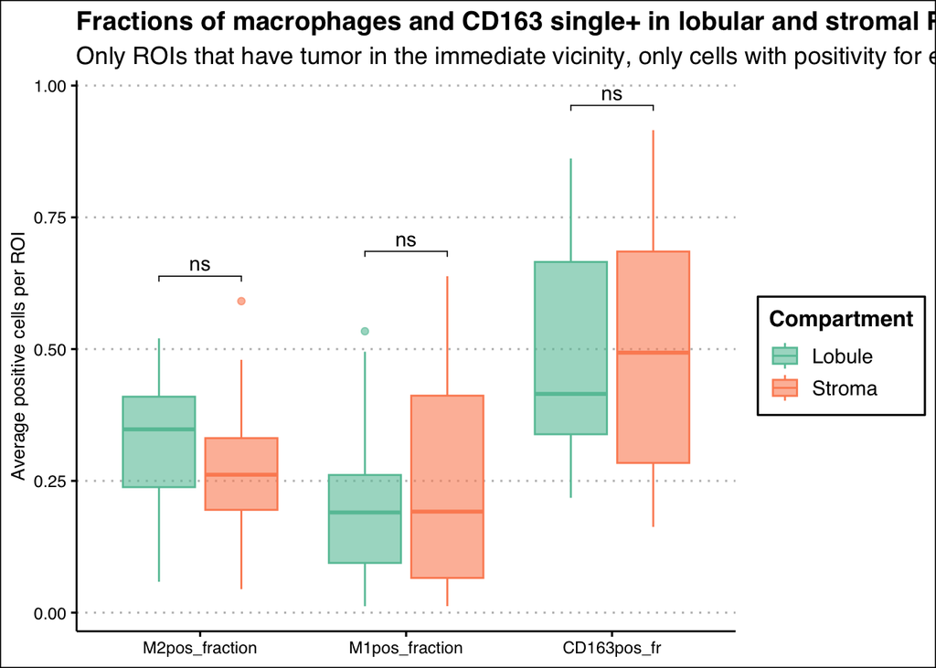

```r
boxes_mo_sign <- boxes_mo + stat_pvalue_manual(label = "p.adj.signif",
                                                    wilcox_mo, tip.length = 0.01)
boxes_mo_sign
```